# presentation-live

## Je rozdíl mezi samci a samicemi u obou forem stejný?

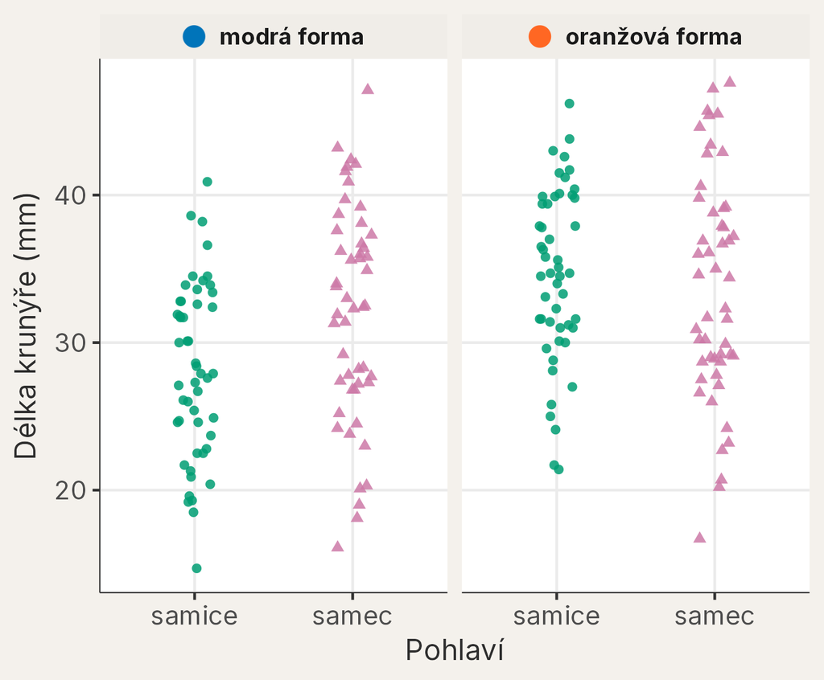

Minuta bez hovoru

Napište pro každou formu:

- kdo má vyšší průměr;
- zda čekáte podobně velký rozdíl;
- jednu větu, kterou z bodů říci nemůžeme.

## Průměry ukazují dva různé rozdíly

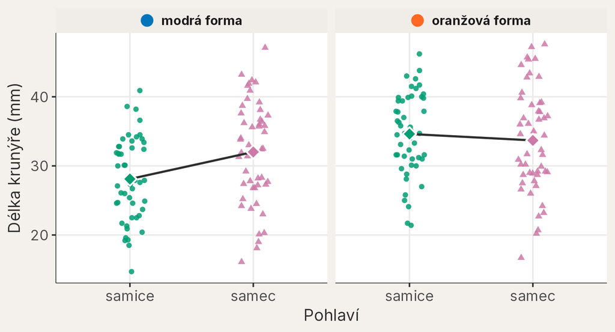

Body, osy i náhodné posunutí jsou stejné. Přibyly pouze průměry a spojnice.

## Jak velký je rozdíl samec minus samice v každé formě?

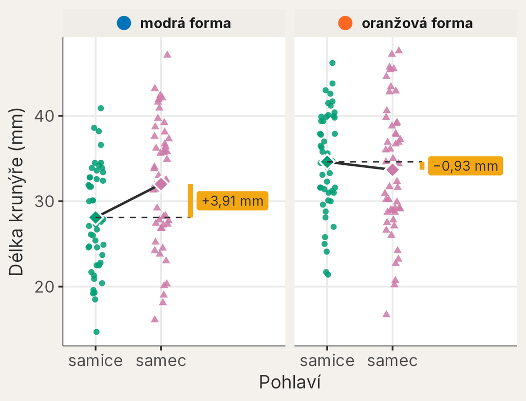

🔵 Modrá forma

$$\text{32,01}
-
\text{28,10}
=
\mathbf{\text{+3,91}\ \text{mm}}$$

🟠 Oranžová forma

$$\text{33,69}
-
\text{34,62}
=
\mathbf{\text{−0,93}\ \text{mm}}$$

U modré formy jsou samci v průměru delší, u oranžové o něco kratší.

## Interakce je rozdíl dvou rozdílů

**Rozdíl dvou rozdílů** $\Delta$ = rozdíl u 🟠 oranžové formy − rozdíl u 🔵 modré formy

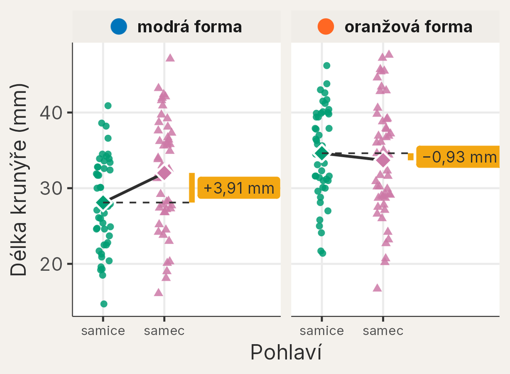

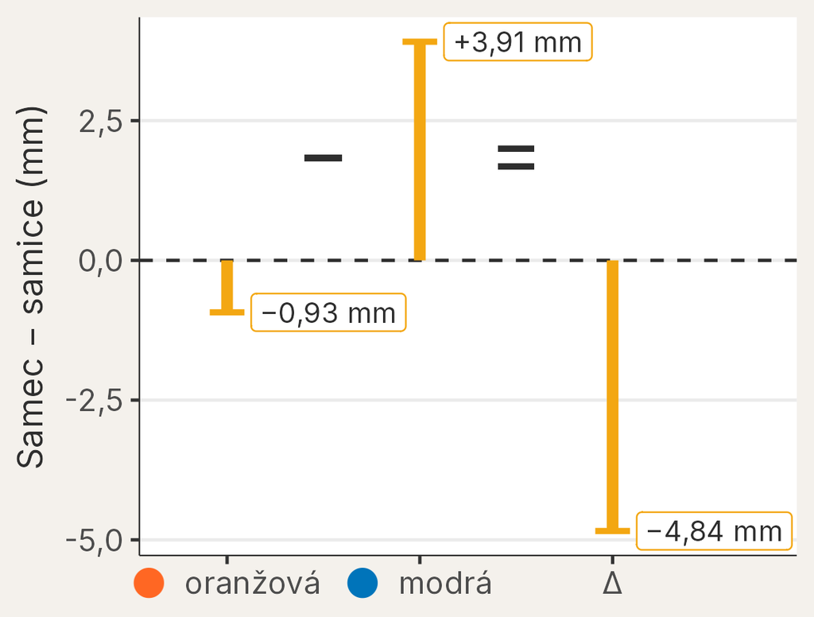

$\Delta = (\text{−0,93}) - (\text{+3,91}) =$ −4,84 mm: o tolik se rozdíl mezi pohlavími změní od modré k oranžové formě.

## Které skupiny jsou referenční?

```r
# První úroveň faktoru je referenční skupina
levels(x = data_formy$forma)
```

```
[1] "modrá"    "oranžová"
```

```r
levels(x = data_formy$pohlavi)
```

```
[1] "samice" "samec"
```

Referenční skupinou jsou samice modré formy: první úroveň obou faktorů. Všechny koeficienty modelu budeme číst vůči této skupině.

## `forma * pohlavi` zapíše všechny čtyři kombinace

`forma * pohlavi` = `forma + pohlavi + forma:pohlavi`

```r
mod_formy <-
  lm(
    formula = delka_krunyre_mm ~ forma * pohlavi,
    data = data_formy
  )
round(
  x = summary(object = mod_formy)$coefficients,
  digits = 3
)
```

```
                           Estimate Std. Error t value Pr(>|t|)
(Intercept)                  28.102      0.950  29.584    0.000
formaoranžová                 6.516      1.343   4.851    0.000
pohlavisamec                  3.912      1.343   2.912    0.004
formaoranžová:pohlavisamec   -4.842      1.900  -2.549    0.012
```

## Který údaj je rozdíl samec − samice v oranžové formě?

| Koeficient | Odhad (mm) |
| --- | --- |
| `(Intercept)` | 28,102 |
| `formaoranžová` | +6,516 |
| `pohlavisamec` | +3,912 |
| `formaoranžová:pohlavisamec` | −4,842 |

**A)** `pohlavisamec`

**B)** `formaoranžová:pohlavisamec`

**C)** `pohlavisamec` + `formaoranžová:pohlavisamec`

**D)** `formaoranžová`

+3,91 + (−4,84) = −0,93 mm: stejný rozdíl, jaký jsme spočítali z průměrů oranžové formy.

## Co znamená každý ze čtyř koeficientů?

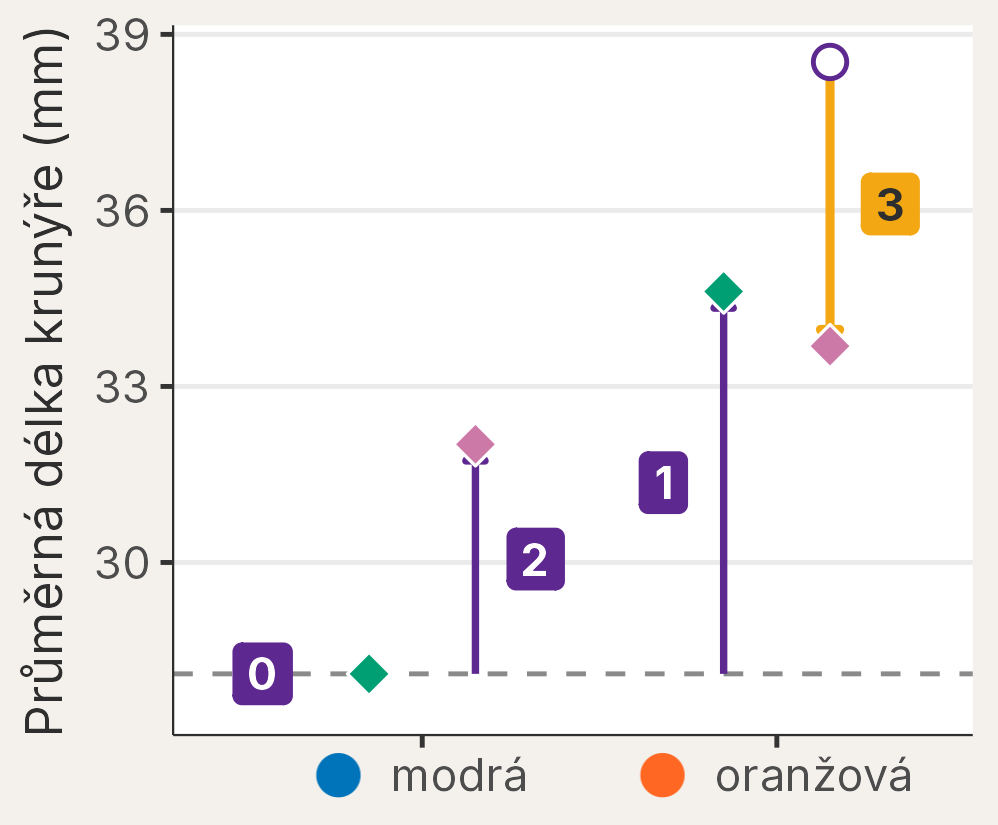

0 `(Intercept)` · 1 `formaoranžová` · 2 `pohlavisamec` · 3 interakce · ○ = bez interakce

[figure not shown]

modrá samice

${\color{#5D2890}{\hat\beta_0}}$ = **28,10 mm**

[figure not shown]

modrý samec

${\color{#5D2890}{\hat\beta_0 + \hat\beta_2}}$ = **32,01 mm**

[figure not shown]

oranžová samice

${\color{#5D2890}{\hat\beta_0 + \hat\beta_1}}$ = **34,62 mm**

[figure not shown]

oranžový samec

${\color{#5D2890}{\hat\beta_0 + \hat\beta_1 + \hat\beta_2}} + \bbox[#F3A712,2pt]{\hat\beta_3}$ = **33,69 mm**

$\bbox[#F3A712,2pt]{\hat\beta_3}$ = −4,84 mm, SE 1,90; 95% interval spolehlivosti −8,59 až −1,10 mm

## Odhadnuté průměry čtyř skupin

```r
prumery_formy <-
  emmeans::emmeans(
    object = mod_formy,
    specs = ~ pohlavi | forma
  )
```

```r
prumery_formy
```

```
forma = modrá:
 pohlavi emmean   SE  df lower.CL upper.CL
 samice    28.1 0.95 196     26.2     30.0
 samec     32.0 0.95 196     30.1     33.9

forma = oranžová:
 pohlavi emmean   SE  df lower.CL upper.CL
 samice    34.6 0.95 196     32.7     36.5
 samec     33.7 0.95 196     31.8     35.6

Confidence level used: 0.95
```

Model má jeden parametr pro každou kombinaci, proto odhadnuté průměry přesně odpovídají pozorovaným skupinovým průměrům.

## Residua jsou odchylky jednotlivých krabů od skupinových průměrů

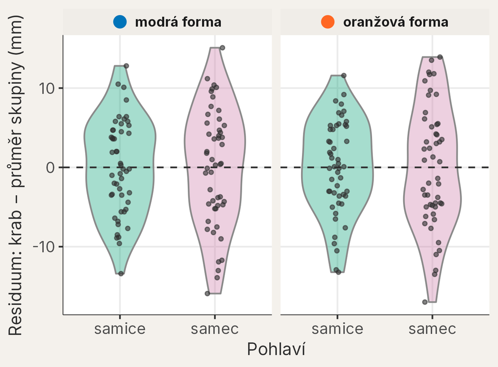

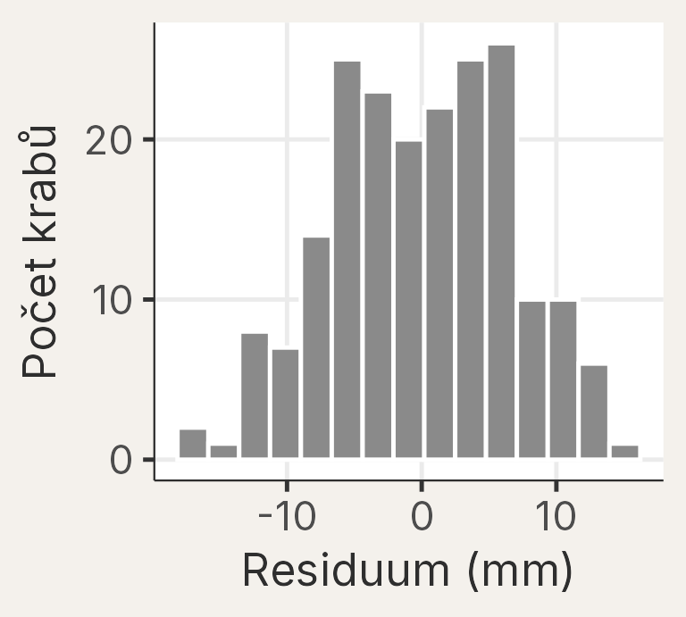

Histogram residuí všech 200 krabů

Residuum = délka kraba − průměr jeho skupiny.

# Když jsou oba prediktory čísla

## Přibude vysokému stromu s každým centimetrem průměru víc dřeva?

Střemcha pozdní

- severoamerický, u nás invazní strom
- objem dřeva z **průměru kmene** a **výšky** (převedeno na cm, m a m³)
- 31 pokácených stromů, chybějící hodnoty: 0
- jeden strom = jeden řádek tabulky = jeden bod v grafu

Ve dvojici

Dva stejně tlusté kmeny ztloustnou o 1 cm. Jeden strom je nízký, druhý vysoký.

Kterému přibude víc dřeva?

Vysokému: nová vrstva dřeva obalí delší kmen.

Meyer (1953), *Forest Mensuration* · `data/stromy.csv`

## Vystihne společný sklon nízké i vysoké stromy?

```r
mod_aditivni <-
  lm(
    formula = objem_m3 ~
      prumer_cm + vyska_m,
    data = data_stromy
  )
```

Průměr a výška: r = 0,52

**Výškové pásmo** je nová kategoriální proměnná jen pro kreslení: barva a tvar bodu. Model dál pracuje s výškou jako s číslem.

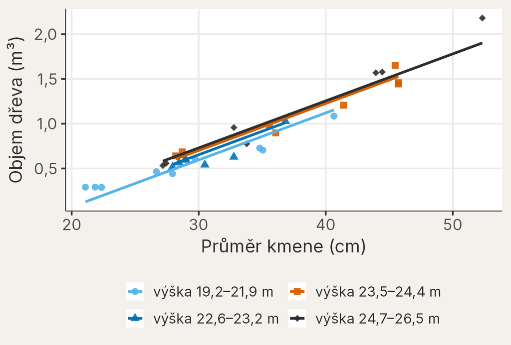

**Ve dvojici:** kde leží tenké a tlusté kmeny krajních pásem vůči své přímce?

## Mění se sklon přímky s výškou stromu?

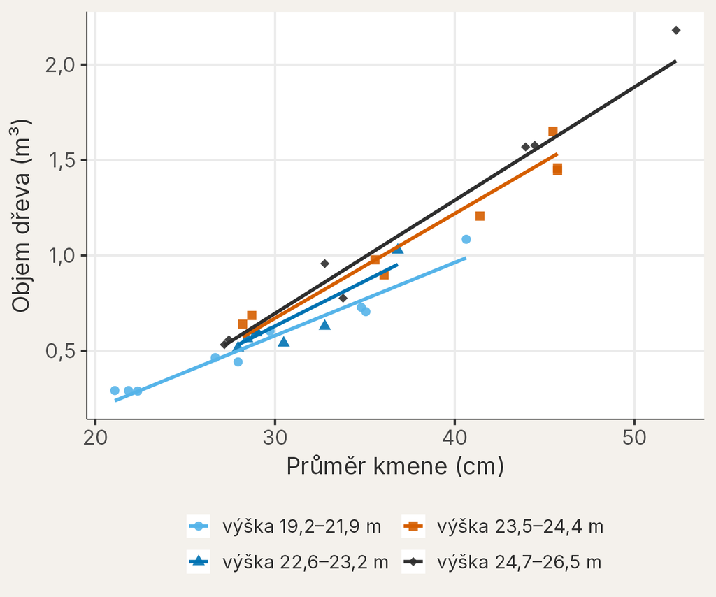

Stejný graf, přímky modelu s interakcí.

Čím vyšší strom, tím strmější přímka.

Sklon = m³ dřeva na 1 cm průměru

## `prumer_cm * vyska_m`: sklon průměru závisí na výšce

```r
mod_stromy <-
  lm(
    formula = objem_m3 ~ prumer_cm * vyska_m,
    data = data_stromy
  )
round(x = coef(object = mod_stromy), digits = 5)
```

```
      (Intercept)         prumer_cm           vyska_m prumer_cm:vyska_m
          1.96508          -0.06528          -0.12050           0.00493
```

## Sklon průměru roste s výškou stromu

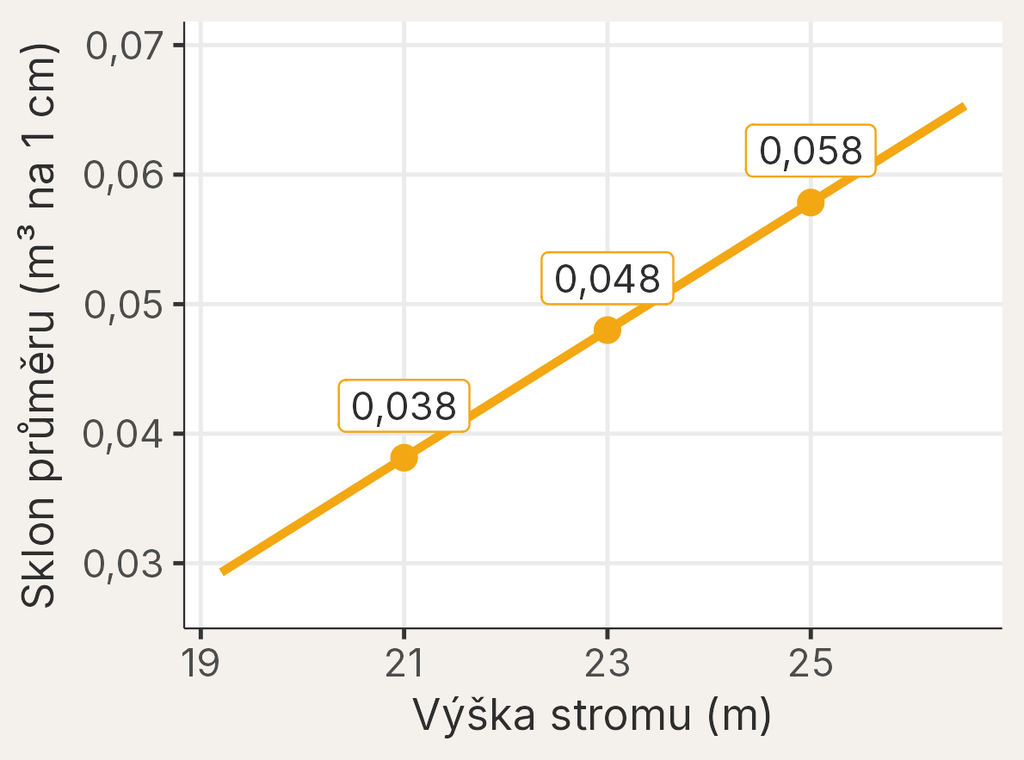

sklon průměru = `prumer_cm` + `prumer_cm:vyska_m` × výška

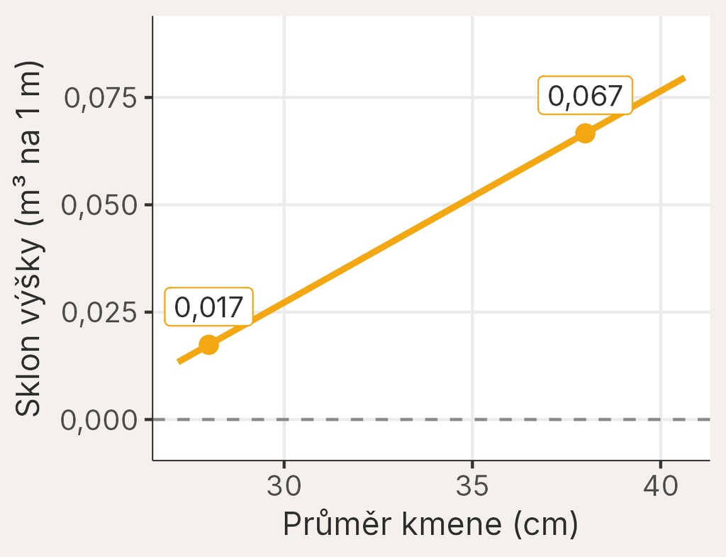

sklon výšky = `vyska_m` + `prumer_cm:vyska_m` × průměr

Pravá přímka jen pro průměry 27–41 cm, kde máme nízké i vysoké stromy.

Interakci lze číst oběma směry: tentýž koeficient 0,0049 mění sklon průměru s výškou i sklon výšky s průměrem.

## Pro který strom platí koeficient `prumer_cm`?

`prumer_cm` = −0,065 m³ na 1 cm

**A)** Pro každý změřený strom.

**B)** Jen pro nejnižší stromy v datech.

**C)** Pro žádný: tlustší kmen má méně dřeva.

**D)** Jen pro strom vysoký 0 m.

Takový strom v datech není. Sklon průměru proto uvádíme při zvolené výšce uvnitř dat.

## Stejný krok průměru dává vyššímu stromu víc dřeva

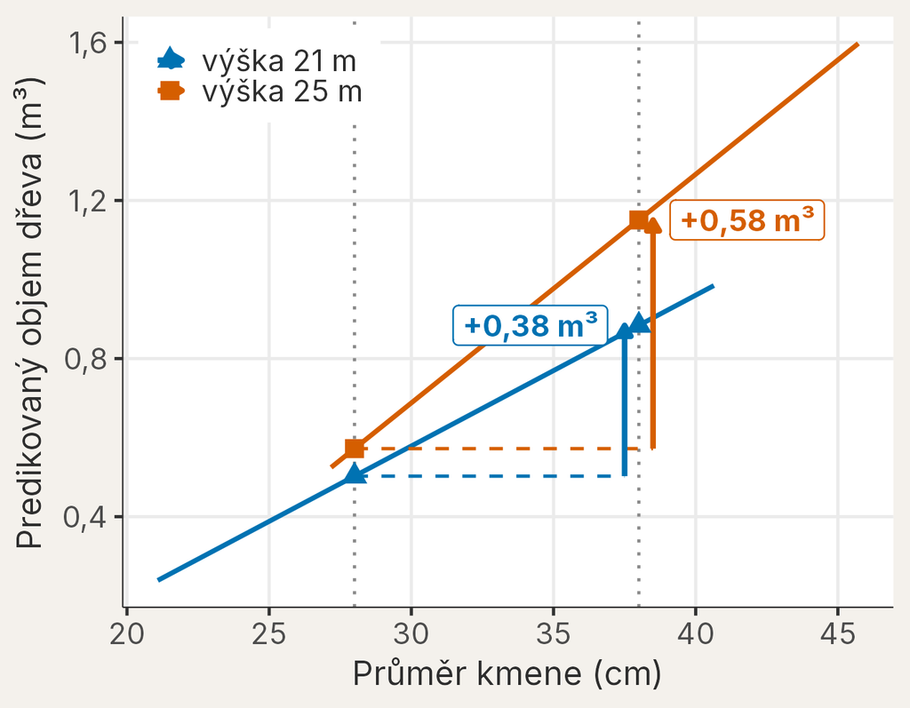

Stejný krok průměru: 28 → 38 cm.

- 21 m: +0,38 m³
- 25 m: +0,58 m³

Po vydělení 10 cm: ≈ 0,038 a 0,058 m³ na 1 cm, tedy sklony průměru při těchto výškách.

## Jak vypadají predikce obou modelů na mapě?

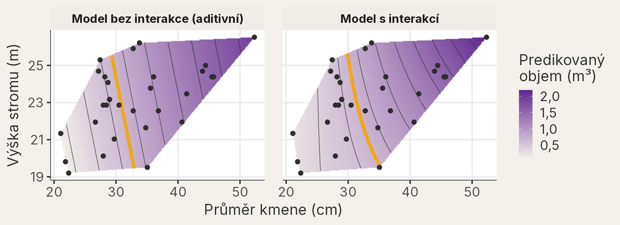

Bod mapy = jedna kombinace průměru a výšky; barva = predikovaný objem; čára = stejný objem (oranžová 0,7 m³).

Čáry stejného objemu: bez interakce rovnoběžné, s interakcí ohnuté.

Mapa jen uvnitř obrysu změřených stromů (57 % obdélníku rozsahů); jinde by model extrapoloval.

## Co víme o stromech?

Přibude vysokému stromu s každým centimetrem průměru víc dřeva?

Co data ukazují

- Kmen 38 cm místo 28 cm podle modelu: +0,38 m³ při 21 m, +0,58 m³ při 25 m.
- Sklon průměru (m³ na 1 cm) roste o 0,0049 na každý 1 m výšky (SE 0,0009; 95% interval spolehlivosti 0,0031 až 0,0068).

Co zůstává otevřené

- 31 stromů bez popsaného výběru.
- Residua stromů jsme nekreslili (krátký příklad); intervaly čtěte jako orientační.
- Cookovu vzdálenost nad 4/n má jeden strom; sklony čteme opatrně.
- Nepopsal by vztah lépe zakřivený model?

# Jedna myšlenka, tři obrazy

## Interakce mění sklon nebo skupinový rozdíl

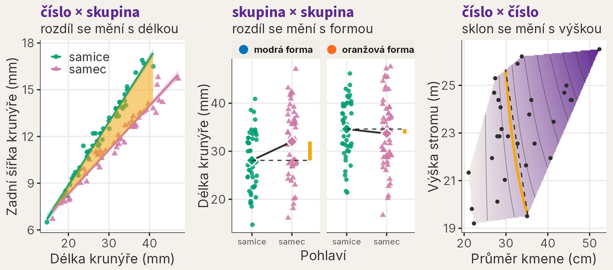

[figure not shown]

Vztah nebo rozdíl závisí na druhém prediktoru.

## Co musíme doplnit, aby tvrzení o efektu bylo úplné?

Neúplné

„Délka má efekt.“

„Samci jsou větší.“

„Průměr kmene má efekt.“

Opravte tvrzení

- Pro které pohlaví?
- Při jaké délce?
- V které barevné formě?
- Větší v jakém znaku?
- Při jaké výšce?

V modelu s interakcí vždy uvádíme hodnotu nebo úroveň druhého prediktoru.

## Jak číst model s interakcí?

[figure not shown]

1. Otázka Mění se vztah nebo rozdíl podle druhého prediktoru?

2. Data a predikce Ukažte body a predikce pro konkrétní kombinace.

3. Koeficienty **Hlavní koeficient** platí v referenční skupině nebo při nule druhého prediktoru.

4. Závěr Jen v rozsahu dat a jako souvislost, ne příčina.

## Co si odnést

[figure not shown]

- Interakci potřebujeme, když vztah jednoho prediktoru závisí na druhém; podpořit ji má biologická otázka i graf.
- `x * y` je zkratka pro `x + y + x:y`.
- Hlavní koeficienty jsou podmíněné; skupiny porovnáváme pomocí predikcí při zvolené hodnotě.
- U dvou kategoriálních prediktorů je interakce rozdíl dvou rozdílů.
- U dvou numerických prediktorů se sklon jednoho plynule mění s hodnotou druhého.
- Závěr omezujeme na pozorovaný rozsah a na souvislost v pozorovacích datech.

Data: Campbell, N. A. a Mahon, R. J. (1974) · Meyer, H. A. (1953) · `data/krabi.csv`, `data/stromy.csv`

## Který biologicky smysluplný model máme zvolit?

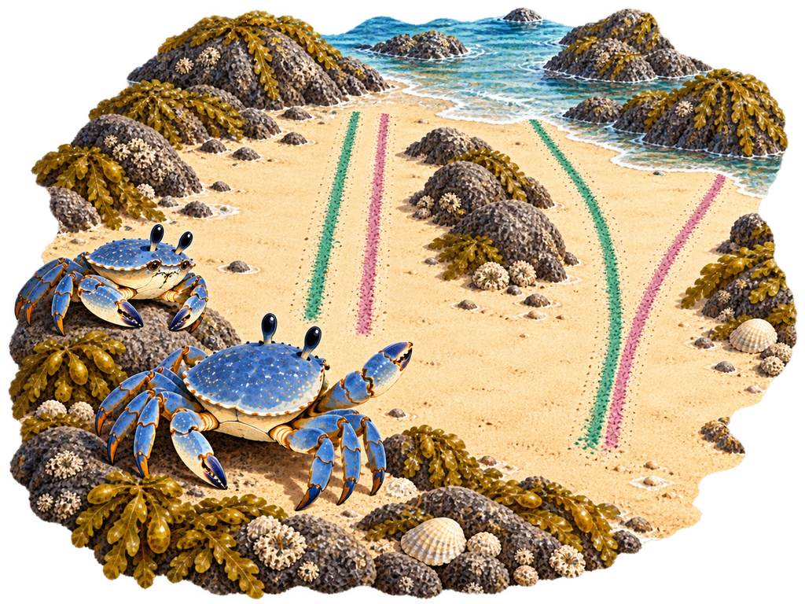

Ilustrace vytvořená pomocí AI.

[figure not shown]

**Model bez interakce (aditivní)**

`zadni_sirka_mm ~`  
`delka_krunyre_mm + pohlavi`

Stálý rozdíl

[figure not shown]

**Model s interakcí**

`zadni_sirka_mm ~`  
`delka_krunyre_mm * pohlavi`

Měnící se rozdíl

Jak mezi těmito modely vybírat, ukáže následující lekce.

## Kde byste čekali interakci vy?

Uveďte biologickou otázku, u které byste čekali, že vztah dvou znaků závisí na skupině nebo na hodnotě jiného znaku.

Jak by vypadal graf?